# ext-Project_Full_Code_Notebook_EasyVisa A.Loskutov v.4 (07272025) - final

[figure not shown]

Data Science and Business Analytics

Ensemble Techniques and Model Tuning

[figure not shown]

Visa Approval Facilitation

# **Problem Statement**

## Context

Business communities in the United States are facing high demand for human resources, but one of the constant challenges is identifying and attracting the right talent, which is perhaps the most important element in remaining competitive. Companies in the United States look for hard-working, talented, and qualified individuals both locally as well as abroad.

The Immigration and Nationality Act (INA) of the US permits foreign workers to come to the United States to work on either a temporary or permanent basis. The act also protects US workers against adverse impacts on their wages or working conditions by ensuring US employers' compliance with statutory requirements when they hire foreign workers to fill workforce shortages. The immigration programs are administered by the Office of Foreign Labor Certification (OFLC).

OFLC processes job certification applications for employers seeking to bring foreign workers into the United States and grants certifications in those cases where employers can demonstrate that there are not sufficient US workers available to perform the work at wages that meet or exceed the wage paid for the occupation in the area of intended employment.

## Objective

In FY 2016, the OFLC processed 775,979 employer applications for 1,699,957 positions for temporary and permanent labor certifications. This was a nine percent increase in the overall number of processed applications from the previous year. The process of reviewing every case is becoming a tedious task as the number of applicants is increasing every year.

The increasing number of applicants every year calls for a Machine Learning based solution that can help in shortlisting the candidates having higher chances of VISA approval. OFLC has hired the firm EasyVisa for data-driven solutions. You as a data scientist at EasyVisa have to analyze the data provided and, with the help of a classification model:

- Facilitate the process of visa approvals.
- Recommend a suitable profile for the applicants for whom the visa should be certified or denied based on the drivers that significantly influence the case status.

## Data Description

The data contains the different attributes of employee and the employer. The detailed data dictionary is given below.

- case_id: ID of each visa application
- continent: Information of continent the employee
- education_of_employee: Information of education of the employee
- has_job_experience: Does the employee has any job experience? Y= Yes; N = No
- requires_job_training: Does the employee require any job training? Y = Yes; N = No
- no_of_employees: Number of employees in the employer's company
- yr_of_estab: Year in which the employer's company was established
- region_of_employment: Information of foreign worker's intended region of employment in the US.
- prevailing_wage: Average wage paid to similarly employed workers in a specific occupation in the area of intended employment. The purpose of the prevailing wage is to ensure that the foreign worker is not underpaid compared to other workers offering the same or similar service in the same area of employment.
- unit_of_wage: Unit of prevailing wage. Values include Hourly, Weekly, Monthly, and Yearly.
- full_time_position: Is the position of work full-time? Y = Full Time Position; N = Part Time Position
- case_status: Flag indicating if the Visa was certified or denied

## Note: This is a sample solution for the project. Projects will NOT be graded on the basis of how well the submission matches this sample solution. Projects will be graded on the basis of the rubric only.

# **Importing necessary libraries**

```python
# Installing the libraries with the specified version.
#!pip install numpy==1.25.2 pandas==1.5.3 scikit-learn==1.2.2 matplotlib==3.7.1 seaborn==0.13.1 xgboost==2.0.3 -q --user
```

```python
!pip install xgboost
```

```python
!pip install catboost lightgbm
```

**Note**: *After running the above cell, kindly restart the notebook kernel and run all cells sequentially from the start again.*

```python
import warnings

warnings.filterwarnings("ignore")

# Libraries to help with reading and manipulating data
import numpy as np
import pandas as pd

# Library to split data
from sklearn.model_selection import train_test_split

# libaries to help with data visualization
import matplotlib.pyplot as plt
import seaborn as sns

from sklearn.model_selection import train_test_split
from sklearn.preprocessing import OneHotEncoder
from sklearn.compose import ColumnTransformer
from sklearn.pipeline import Pipeline
from catboost import CatBoostClassifier
from sklearn.model_selection import RandomizedSearchCV
from sklearn import metrics

# Removes the limit for the number of displayed columns
pd.set_option("display.max_columns", None)
# Sets the limit for the number of displayed rows
pd.set_option("display.max_rows", 100)

# To oversample and undersample data
from imblearn.over_sampling import SMOTE
from imblearn.under_sampling import RandomUnderSampler

# Libraries different ensemble classifiers
# Libraries for different ensemble classifiers
from sklearn.ensemble import (
    BaggingClassifier,
    RandomForestClassifier,
    AdaBoostClassifier,
    GradientBoostingClassifier,
    StackingClassifier,
)

from sklearn.tree import DecisionTreeClassifier
from xgboost import XGBClassifier
from lightgbm import LGBMClassifier
from catboost import CatBoostClassifier

# Libraries to get different metric scores
from sklearn import metrics
from sklearn.metrics import (
    confusion_matrix,
    accuracy_score,
    precision_score,
    recall_score,
    f1_score,
)

# To tune different models
from sklearn.model_selection import GridSearchCV
```

# **Loading the dataset**

```python
data = pd.read_csv("EasyVisa.csv")


'''from google.colab import drive
drive.mount('/content/drive')
file_path = '/content/drive/MyDrive/Austin/06. Ensemble Techniques and Model Tuning/!2.7 Project Ensemble Techniques and Model Tuning EasyVisa/EasyVisa.csv'
data = pd.read_csv(file_path)'''
```

```
"from google.colab import drive\ndrive.mount('/content/drive')\nfile_path = '/content/drive/MyDrive/Austin/06. Ensemble Techniques and Model Tuning/!2.7 Project Ensemble Techniques and Model Tuning EasyVisa/EasyVisa.csv'\ndata = pd.read_csv(file_path)"
```

```python
# copying data to another varaible to avoid any changes to original data
df = data.copy()
```

# **Overview of the Dataset**

- Observations
- Sanity checks

### View the first and last 5 rows of the dataset.

```python
df.head()
```

|  | case_id | continent | education_of_employee | has_job_experience | requires_job_training | no_of_employees | yr_of_estab | region_of_employment | prevailing_wage | unit_of_wage | full_time_position | case_status |
| --- | --- | --- | --- | --- | --- | --- | --- | --- | --- | --- | --- | --- |
| 0 | EZYV01 | Asia | High School | N | N | 14513 | 2007 | West | 592.2029 | Hour | Y | Denied |
| 1 | EZYV02 | Asia | Master's | Y | N | 2412 | 2002 | Northeast | 83425.6500 | Year | Y | Certified |
| 2 | EZYV03 | Asia | Bachelor's | N | Y | 44444 | 2008 | West | 122996.8600 | Year | Y | Denied |
| 3 | EZYV04 | Asia | Bachelor's | N | N | 98 | 1897 | West | 83434.0300 | Year | Y | Denied |
| 4 | EZYV05 | Africa | Master's | Y | N | 1082 | 2005 | South | 149907.3900 | Year | Y | Certified |

```python
df.tail()
```

|  | case_id | continent | education_of_employee | has_job_experience | requires_job_training | no_of_employees | yr_of_estab | region_of_employment | prevailing_wage | unit_of_wage | full_time_position | case_status |
| --- | --- | --- | --- | --- | --- | --- | --- | --- | --- | --- | --- | --- |
| 25475 | EZYV25476 | Asia | Bachelor's | Y | Y | 2601 | 2008 | South | 77092.57 | Year | Y | Certified |
| 25476 | EZYV25477 | Asia | High School | Y | N | 3274 | 2006 | Northeast | 279174.79 | Year | Y | Certified |
| 25477 | EZYV25478 | Asia | Master's | Y | N | 1121 | 1910 | South | 146298.85 | Year | N | Certified |
| 25478 | EZYV25479 | Asia | Master's | Y | Y | 1918 | 1887 | West | 86154.77 | Year | Y | Certified |
| 25479 | EZYV25480 | Asia | Bachelor's | Y | N | 3195 | 1960 | Midwest | 70876.91 | Year | Y | Certified |

### Understand the shape of the dataset.

```python
df.shape
```

```
(25480, 12)
```

The dataset has 25480 rows and 12 columns of data

### Check the data types of the columns for the dataset.

```python
df.info()
```

```
<class 'pandas.core.frame.DataFrame'>
RangeIndex: 25480 entries, 0 to 25479
Data columns (total 12 columns):
 #   Column                 Non-Null Count  Dtype
---  ------                 --------------  -----
 0   case_id                25480 non-null  object
 1   continent              25480 non-null  object
 2   education_of_employee  25480 non-null  object
 3   has_job_experience     25480 non-null  object
 4   requires_job_training  25480 non-null  object
 5   no_of_employees        25480 non-null  int64
 6   yr_of_estab            25480 non-null  int64
 7   region_of_employment   25480 non-null  object
 8   prevailing_wage        25480 non-null  float64
 9   unit_of_wage           25480 non-null  object
 10  full_time_position     25480 non-null  object
 11  case_status            25480 non-null  object
dtypes: float64(1), int64(2), object(9)
memory usage: 2.3+ MB
```

### Summary of the dataset.

```python
df.describe(include="all")
```

|  | case_id | continent | education_of_employee | has_job_experience | requires_job_training | no_of_employees | yr_of_estab | region_of_employment | prevailing_wage | unit_of_wage | full_time_position | case_status |
| --- | --- | --- | --- | --- | --- | --- | --- | --- | --- | --- | --- | --- |
| count | 25480 | 25480 | 25480 | 25480 | 25480 | 25480.000000 | 25480.000000 | 25480 | 25480.000000 | 25480 | 25480 | 25480 |
| unique | 25480 | 6 | 4 | 2 | 2 | NaN | NaN | 5 | NaN | 4 | 2 | 2 |
| top | EZYV01 | Asia | Bachelor's | Y | N | NaN | NaN | Northeast | NaN | Year | Y | Certified |
| freq | 1 | 16861 | 10234 | 14802 | 22525 | NaN | NaN | 7195 | NaN | 22962 | 22773 | 17018 |
| mean | NaN | NaN | NaN | NaN | NaN | 5667.043210 | 1979.409929 | NaN | 74455.814592 | NaN | NaN | NaN |
| std | NaN | NaN | NaN | NaN | NaN | 22877.928848 | 42.366929 | NaN | 52815.942327 | NaN | NaN | NaN |
| min | NaN | NaN | NaN | NaN | NaN | -26.000000 | 1800.000000 | NaN | 2.136700 | NaN | NaN | NaN |
| 25% | NaN | NaN | NaN | NaN | NaN | 1022.000000 | 1976.000000 | NaN | 34015.480000 | NaN | NaN | NaN |
| 50% | NaN | NaN | NaN | NaN | NaN | 2109.000000 | 1997.000000 | NaN | 70308.210000 | NaN | NaN | NaN |
| 75% | NaN | NaN | NaN | NaN | NaN | 3504.000000 | 2005.000000 | NaN | 107735.512500 | NaN | NaN | NaN |
| max | NaN | NaN | NaN | NaN | NaN | 602069.000000 | 2016.000000 | NaN | 319210.270000 | NaN | NaN | NaN |

### Observations

1. **Unique Cases**
   - Each record represents a unique case, as `case_id` has 25,480 unique values.
2. **Geographic Distribution**
   - The majority of employees are from **Asia** (16,861 out of 25,480 cases), indicating strong representation from this continent.
3. **Education Background**
   - The most common education level is **Bachelor's degree**, representing around 40% of the total dataset.
4. **Job Experience and Training Requirements**
   - A significant number of applicants **have prior job experience** (`Y` = 14,802).
   - Most job roles **do not require job training** (`N` = 22,525), suggesting they are intended for experienced candidates.
5. **Employment Type**
   - The vast majority of positions are **full-time** (`Y` = 22,773).
   - **Yearly wage** is the most common wage unit, used in 22,962 cases.
6. **Case Outcome**
   - About **two-thirds of the cases were certified** (`Certified` = 17,018), indicating a high approval rate.
7. **Numerical Variables**
   - `no_of_employees` has a wide range (from -26 to over 600,000). The **negative value suggests data quality issues**.
   - `yr_of_estab` ranges from **1800 to 2016**. Dates before the 1900s may be **inaccurate or misentered**.
   - `prevailing_wage` varies greatly, with a **high standard deviation**, indicating wage disparity across roles or industries.
8. **Regional Employment**
   - The most common region of employment is the **Northeast** (7,195 cases), suggesting job concentration in that area.

```python
# checking for unique values in case_id column
df["case_id"].nunique()
```

```
25480
```

```python
df.drop(["case_id"], axis=1, inplace=True)
```

### Check for missing values

```python
df.isnull().sum()
```

```
continent                0
education_of_employee    0
has_job_experience       0
requires_job_training    0
no_of_employees          0
yr_of_estab              0
region_of_employment     0
prevailing_wage          0
unit_of_wage             0
full_time_position       0
case_status              0
dtype: int64
```

- There are no missing values in the dataset

Check negative values of no_of_employees

```python
df.loc[df["no_of_employees"] < 0].shape
```

```
(33, 11)
```

Drop data with negative values of no_of_employees becuase there are only 33

```python
df = df.loc[df["no_of_employees"] >= 0]
```

# **Exploratory Data Analysis (EDA)**

- EDA is an important part of any project involving data.
- It is important to investigate and understand the data better before building a model with it.
- A few questions have been mentioned below which will help you approach the analysis in the right manner and generate insights from the data.
- A thorough analysis of the data, in addition to the questions mentioned below, should be done.

**Leading Questions**

What is the distribution of visa case statuses (certified vs. denied)?

1. What is the distribution of visa case statuses (certified vs. denied)?
2. How does the education level of employees impact visa approval rates?
3. Is there a significant difference in visa approval rates between employees with and without prior job experience?
4. How does the prevailing wage affect visa approval? Do higher wages lead to higher chances of approval?
5. Do certain regions in the US have higher visa approval rates compared to others?
6. How does the number of employees in a company influence visa approval? Do larger companies have a higher approval rate?
7. Are visa approval rates different across various continents of employees? Which continent has the highest and lowest approval rates?

```python
# function to create labeled barplots
def labeled_barplot(data, feature, perc=False, n=None):
    """
    Barplot with percentage at the top

    data: dataframe
    feature: dataframe column
    perc: whether to display percentages instead of count (default is False)
    n: displays the top n category levels (default is None, i.e., display all levels)
    """

    total = len(data[feature])  # length of the column
    count = data[feature].nunique()
    if n is None:
        plt.figure(figsize=(count + 2, 6))
    else:
        plt.figure(figsize=(n + 2, 6))

    plt.xticks(rotation=90, fontsize=15)
    ax = sns.countplot(
        data=data,
        x=feature,
        palette="Paired",
        order=data[feature].value_counts().index[:n],
    )

    for p in ax.patches:
        if perc == True:
            label = "{:.1f}%".format(
                100 * p.get_height() / total
            )  # percentage of each class of the category
        else:
            label = p.get_height()  # count of each level of the category

        x = p.get_x() + p.get_width() / 2  # width of the plot
        y = p.get_height()  # height of the plot

        ax.annotate(
            label,
            (x, y),
            ha="center",
            va="center",
            size=12,
            xytext=(0, 5),
            textcoords="offset points",
        )  # annotate the percentage

    plt.show()  # show the plot
```

```python
# function to plot stacked bar chart
def stacked_barplot(data, predictor, target):
    """
    Print the category counts and plot a stacked bar chart

    data: dataframe
    predictor: independent variable
    target: target variable
    """
    count = data[predictor].nunique()
    sorter = data[target].value_counts().index[-1]
    tab1 = pd.crosstab(data[predictor], data[target], margins=True).sort_values(
        by=sorter, ascending=False
    )
    print(tab1)
    print("-" * 120)
    tab = pd.crosstab(data[predictor], data[target], normalize="index").sort_values(
        by=sorter, ascending=False
    )
    tab.plot(kind="bar", stacked=True, figsize=(count + 5, 6))
    plt.legend(
        loc="lower left", frameon=False,
    )
    plt.legend(loc="upper left", bbox_to_anchor=(1, 1))
    plt.show()
```

```python
def histogram_boxplot(data, feature, figsize=(15, 10), kde=False, bins=None):
    """
    Boxplot and histogram combined

    data: dataframe
    feature: dataframe column
    figsize: size of figure (default (15,10))
    kde: whether to show the density curve (default False)
    bins: number of bins for histogram (default None)
    """
    f2, (ax_box2, ax_hist2) = plt.subplots(
        nrows=2,  # Number of rows of the subplot grid= 2
        sharex=True,  # x-axis will be shared among all subplots
        gridspec_kw={"height_ratios": (0.25, 0.75)},
        figsize=figsize,
    )  # creating the 2 subplots
    sns.boxplot(
        data=data, x=feature, ax=ax_box2, showmeans=True, color="violet"
    )  # boxplot will be created and a triangle will indicate the mean value of the column
    sns.histplot(
        data=data, x=feature, kde=kde, ax=ax_hist2, bins=bins
    ) if bins else sns.histplot(
        data=data, x=feature, kde=kde, ax=ax_hist2
    )  # For histogram
    ax_hist2.axvline(
        data[feature].mean(), color="green", linestyle="--"
    )  # Add mean to the histogram
    ax_hist2.axvline(
        data[feature].median(), color="black", linestyle="-"
    )  # Add median to the histogram
```

```python
### function to plot distributions wrt target


def distribution_plot_wrt_target(data, predictor, target):

    fig, axs = plt.subplots(2, 2, figsize=(12, 10))

    target_uniq = data[target].unique()

    axs[0, 0].set_title("Distribution of target for target=" + str(target_uniq[0]))
    sns.histplot(
        data=data[data[target] == target_uniq[0]],
        x=predictor,
        kde=True,
        ax=axs[0, 0],
        color="teal",
        stat="density",
    )

    axs[0, 1].set_title("Distribution of target for target=" + str(target_uniq[1]))
    sns.histplot(
        data=data[data[target] == target_uniq[1]],
        x=predictor,
        kde=True,
        ax=axs[0, 1],
        color="orange",
        stat="density",
    )

    axs[1, 0].set_title("Boxplot w.r.t target")
    sns.boxplot(data=data, x=target, y=predictor, ax=axs[1, 0], palette="gist_rainbow")

    axs[1, 1].set_title("Boxplot (without outliers) w.r.t target")
    sns.boxplot(
        data=data,
        x=target,
        y=predictor,
        ax=axs[1, 1],
        showfliers=False,
        palette="gist_rainbow",
    )

    plt.tight_layout()
    plt.show()
```

### Univariate analysis

#### Observations on continent

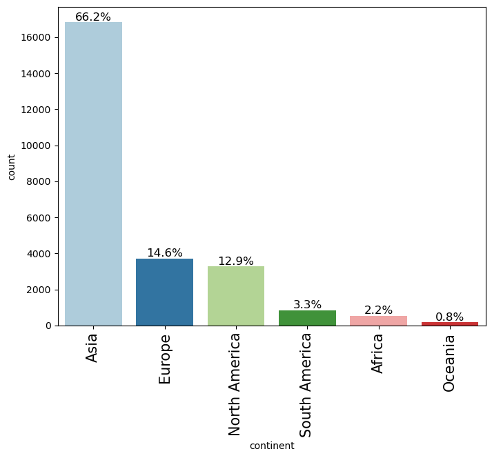

```python
labeled_barplot(df, "continent", perc=True)
```

- The dataset is **highly imbalanced** in terms of continent representation.
- **Asia** dominates the data, accounting for **66.2%** of all cases.
- **Europe** and **North America** follow with **14.6%** and **12.9%**, respectively.
- **South America (3.3%)**, **Africa (2.2%)**, and **Oceania (0.8%)** are **minimally represented**.
- This skewed distribution may introduce **geographical bias** in model training and should be addressed during analysis or modeling.

#### Observations on education_of_employee

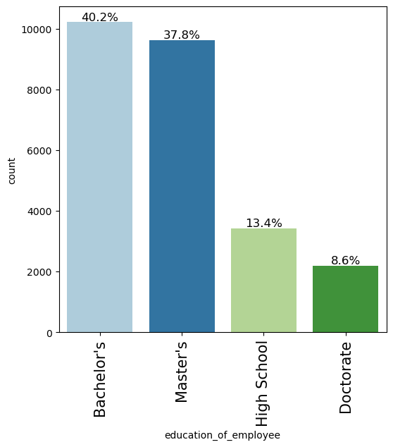

```python
labeled_barplot(df, "education_of_employee", perc=True)
```

- The dataset is predominantly composed of employees with **Bachelor's degrees (40.2%)** and **Master's degrees (37.8%)**.
- Together, these two categories account for nearly **78% of the total cases**, indicating a highly educated workforce.
- **High School** graduates make up **13.4%** of the data, showing a smaller but notable segment of less formally educated workers.
- **Doctorate holders** represent the smallest group at **8.6%**.
- The data indicates that the job market in this dataset is primarily geared toward candidates with **undergraduate or postgraduate qualifications**.

#### Observations on has_job_experience

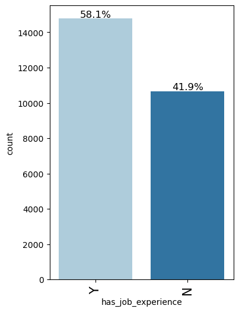

```python
labeled_barplot(df, "has_job_experience", perc=True)
```

- A majority of the individuals in the dataset **have prior job experience**.
- **58.1%** of the applicants reported having job experience (`Y`), while **41.9%** reported having none (`N`).
- This indicates that the dataset is slightly skewed toward **experienced candidates**, which may influence the outcomes of job-related analyses or models.
- Depending on the use case, it may be valuable to examine how experience impacts wage levels or case approval status.

#### Observations on requires_job_training

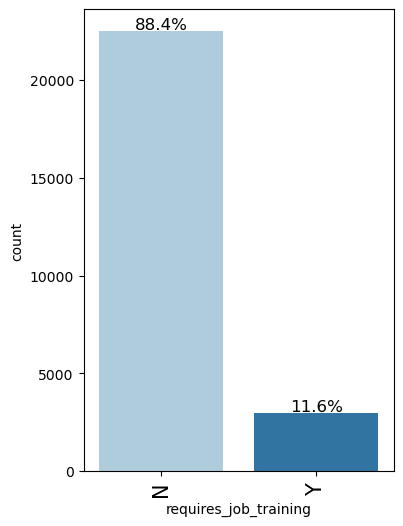

```python
labeled_barplot(df, "requires_job_training", perc=True)
```

- The vast majority of positions in the dataset **do not require job training**.
- **88.4%** of cases are marked as `N` (no training required), while only **11.6%** require training (`Y`).
- This suggests that most job roles are likely intended for candidates who are already equipped with the necessary skills.
- The imbalance may indicate that training-intensive roles are relatively rare or reserved for specialized positions.
- This feature could be a strong indicator of job complexity or wage expectations.

#### Observations on yr_of_estab

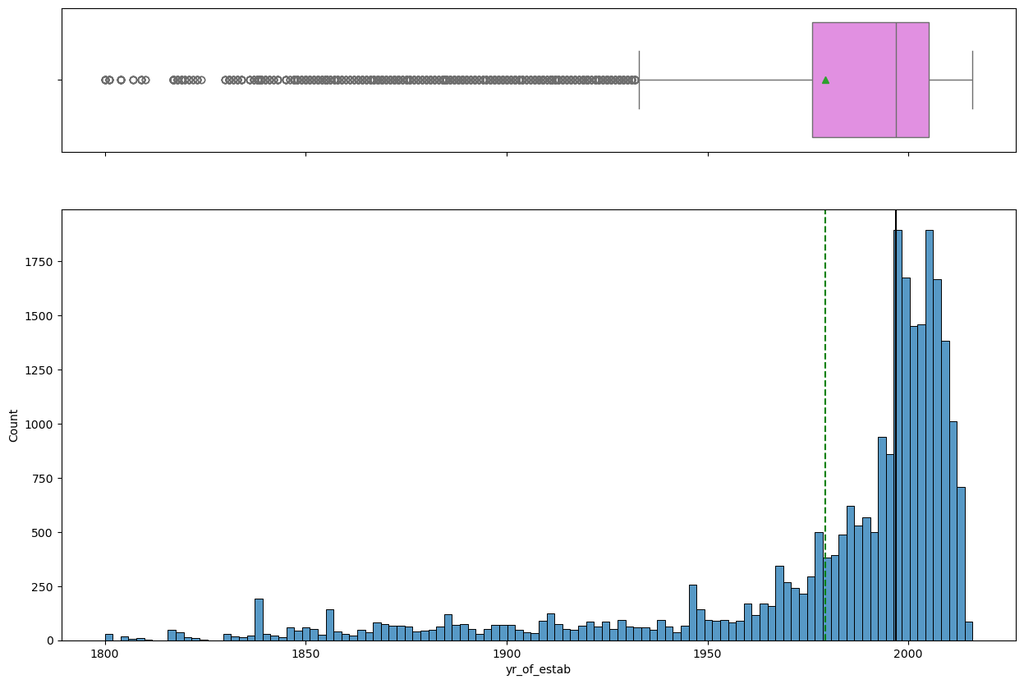

```python
histogram_boxplot(df, "yr_of_estab")
```

- The majority of companies in the dataset were established **after 1980**, with a significant concentration from the **1990s to early 2000s**.
- A **long tail of older establishments** extends back to the **1800s**, with some entries even before 1850.
- The **boxplot shows a wide range with many outliers**, particularly on the earlier end (pre-1950).
- These early years may represent **data entry errors or special historical cases**, especially entries prior to 1900.
- Data cleanup may be required to handle **outliers or improbable establishment years** for better model reliability.
- The distribution suggests that most businesses represented are **modern, possibly tech-focused or post-industrial**.

#### Observations on region_of_employment

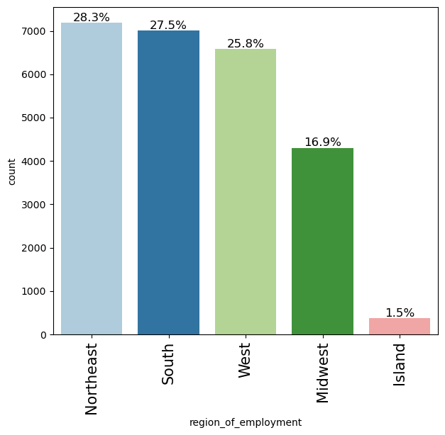

```python
labeled_barplot(df, "region_of_employment", perc=True)
```

- The distribution of employment across U.S. regions is **relatively balanced** among the top three:
  - **Northeast**: 28.3%
  - **South**: 27.5%
  - **West**: 25.8%
- These three regions collectively account for over **81%** of the dataset.
- **Midwest** follows with 16.9%, showing moderate representation.
- **Island regions** (likely U.S. territories such as Puerto Rico or Guam) have a **very small presence** at 1.5%.
- This distribution indicates that most employment opportunities in the dataset are concentrated in the **continental U.S.**, especially in the **Northeast, South, and West**.

#### Observations on prevailing_wage

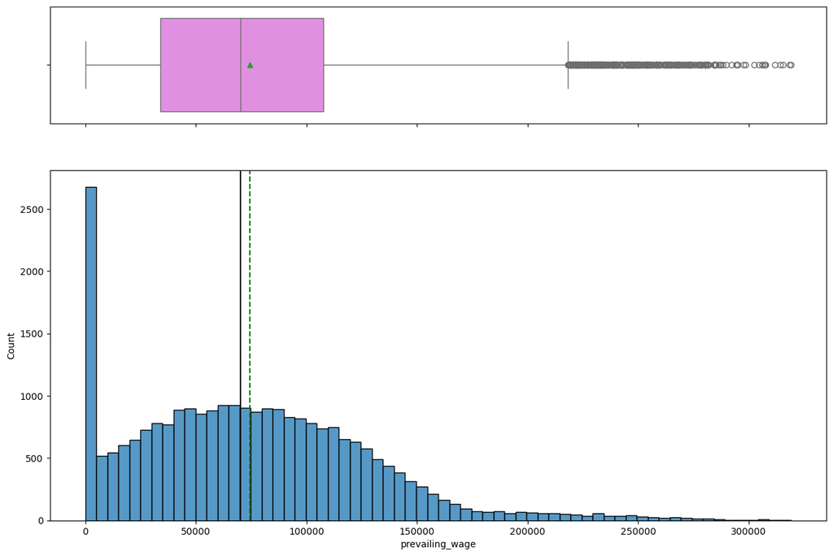

```python
histogram_boxplot(df, "prevailing_wage")
```

#### Observations on unit_of_wage

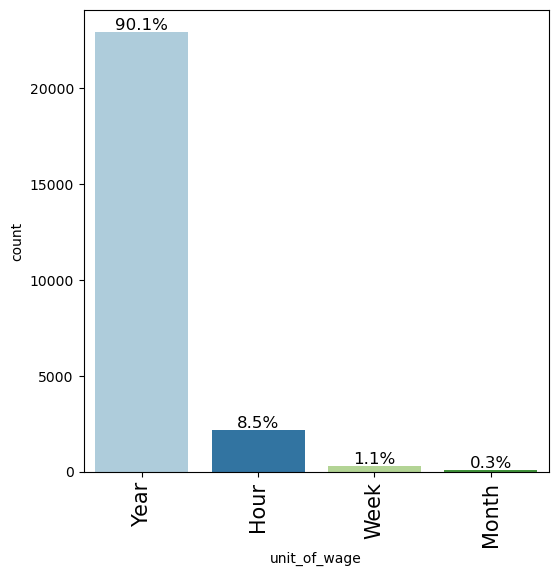

```python
labeled_barplot(df, "unit_of_wage", perc=True)
```

- The vast majority of wage records are reported on a **Yearly basis (90.1%)**, indicating that annual salaries are the standard in this dataset.
- **Hourly wages** account for **8.5%**, which may represent part-time or hourly contract roles.
- **Weekly (1.1%)** and **Monthly (0.3%)** units are **rare**, making them minor components of the overall dataset.
- This skewed distribution suggests that any wage standardization or comparison across records should consider converting all values to a **common unit**, preferably annual.
- It's important to normalize wages before analysis, especially if using wage as a feature in modeling.

#### Observations on full_time_position

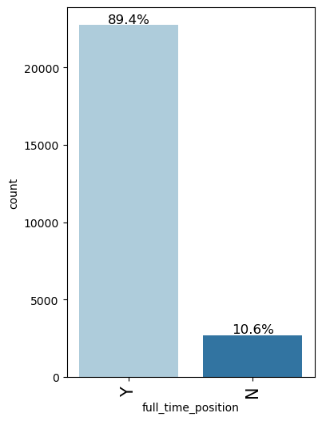

```python
labeled_barplot(df, "full_time_position", perc=True)
```

- The majority of roles in the dataset are **full-time positions**, accounting for **89.4%** of all records.
- Only **10.6%** of the cases are for **part-time or non-full-time roles**.
- This indicates a **strong preference or demand for full-time employment** in the dataset.
- Analysis involving working hours, benefits, or wage expectations should account for this imbalance.
- If comparing job types or outcomes, it may be helpful to treat full-time vs. part-time as a significant categorical variable.

#### Observations on case_status

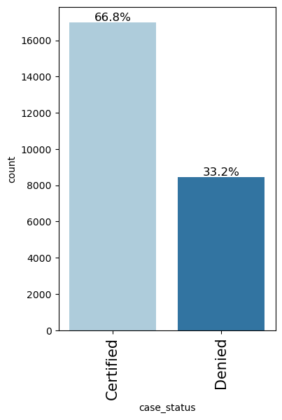

```python
labeled_barplot(df, "case_status", perc=True)
```

- Approximately **66.8%** of the applications in the dataset are **Certified**, indicating a relatively high approval rate.
- **33.2%** of the cases are **Denied**, representing a substantial portion of the datasetion.

### continent vs case_status

```
case_status    Certified  Denied    All
continent
All                17001    8446  25447
Asia               11001    5839  16840
North America       2037    1250   3287
Europe              2953     774   3727
South America        492     359    851
Africa               396     154    550
Oceania              122      70    192
------------------------------------------------------------------------------------------------------------------------
```

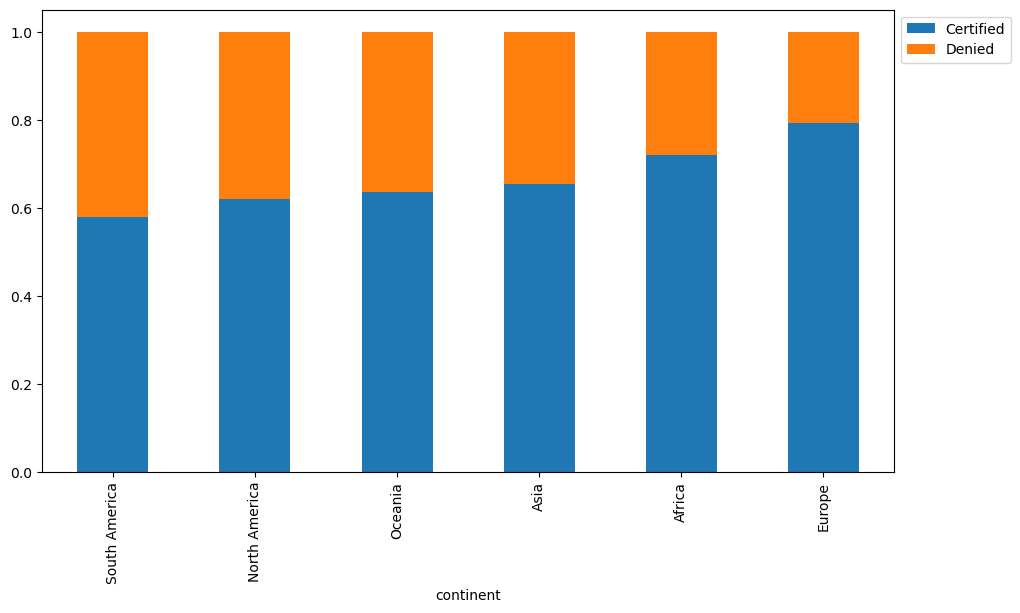

```python
stacked_barplot(df, "continent", "case_status")
```

- The overall certification rate is approximately **66.8%**, but it **varies by continent**:
  - **Europe** has the **highest certification rate** (~79%) among all continents.
  - **Africa** also shows a **strong approval rate** (~72%).
  - **Asia** and **Oceania** follow with certification rates of approximately **66% and 64%**, respectively.
  - **North America** and **South America** have the **lowest certification rates**, around **62% and 58%**.
- While **Asia** has the highest number of total cases, the approval rate is **close to the global average**.
- This suggests that **region of origin may influence case outcomes**, possibly due to varying applicant profiles, employer practices, or systemic factors.
- These patterns may warrant further investigation into how **continent-specific features** (e.g., education, experience, job roles) relate to approval likelihood.

### education_of_employee vs case_status

```
case_status            Certified  Denied    All
education_of_employee
All                        17001    8446  25447
Bachelor's                  6362    3858  10220
High School                 1164    2252   3416
Master's                    7565    2057   9622
Doctorate                   1910     279   2189
------------------------------------------------------------------------------------------------------------------------
```

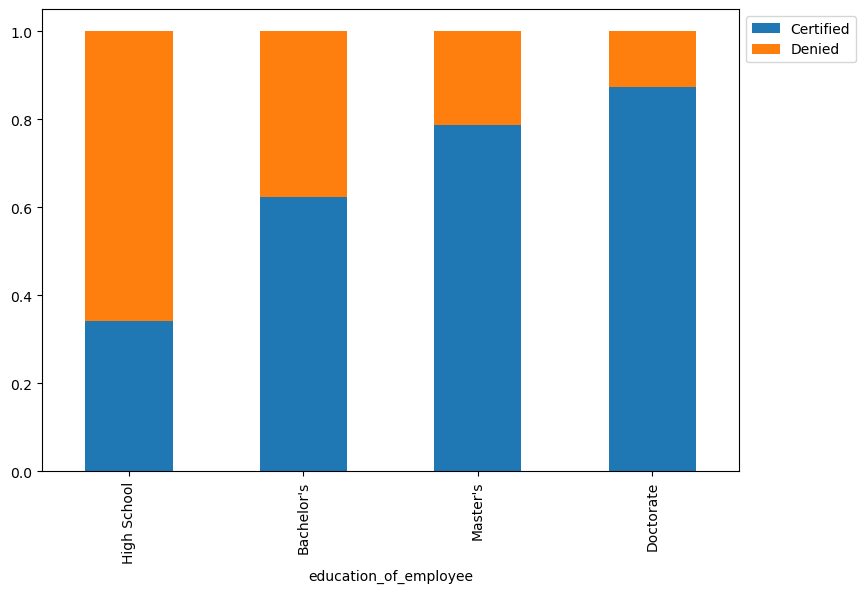

```python
stacked_barplot(df, "education_of_employee", "case_status")
```

```
case_status            Certified  Denied    All
requires_job_training
All                        17001    8446  25447
N                          15000    7498  22498
Y                           2001     948   2949
------------------------------------------------------------------------------------------------------------------------
```

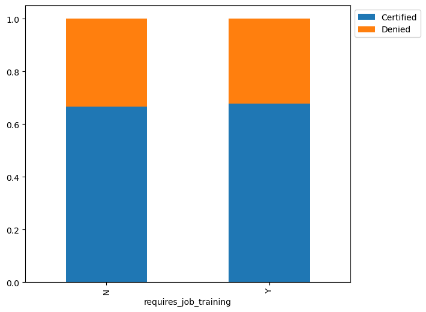

```python
stacked_barplot(df, "requires_job_training", "case_status")
```

- The certification rates are **very similar** for both groups:
  - **Applicants not requiring job training (`N`)**: ~66.7% certified
  - **Applicants requiring job training (`Y`)**: ~67.9% certified
- Despite assumptions that training needs might affect case outcomes, the data shows **no significant difference** in approval likelihood based on this variable alone.
- Breakdown of total cases:
  - `N`: 22,498 cases (15,000 certified, 7,498 denied)
  - `Y`: 2,949 cases (2,001 certified, 948 denied)
- The **proportion of certifications remains stable**, regardless of job training requirement.
- While this feature may not be a strong individual predictor, it could still be **useful in interaction with other variables** (e.g., experience or education level).
- The **likelihood of case certification increases with the level of education**.
- **Doctorate holders** have the **highest certification rate** (~87%), followed by:
  - **Master’s degree** holders (~79%)
  - **Bachelor’s degree** holders (~62%)
  - **High School** graduates have the **lowest approval rate**, with only ~34% of cases certified.
- The **denial rate is highest among High School graduates**, making up nearly two-thirds of that group.
- This trend highlights a **strong positive correlation between educational attainment and case approval**.
- It suggests that higher education may be a significant factor in decision-making, possibly due to perceived skill level, job type, or wage thresholds.
- These insights may inform feature importance in predictive modeling or guide policy discussions around visa eligibility and qualifications.

### has_job_experience", "case_status

```
case_status         Certified  Denied    All
has_job_experience
All                     17001    8446  25447
N                        5986    4675  10661
Y                       11015    3771  14786
------------------------------------------------------------------------------------------------------------------------
```

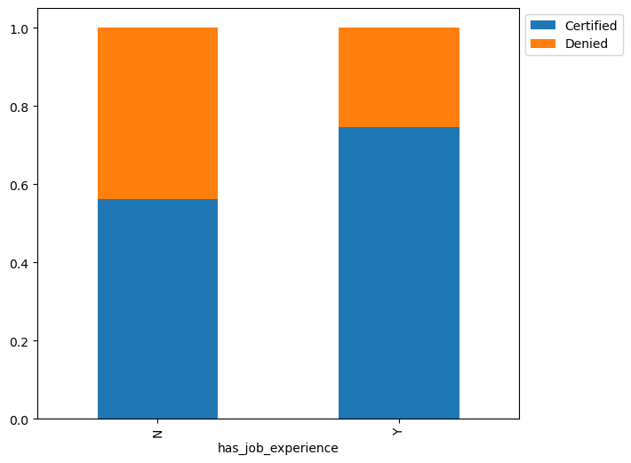

```python
stacked_barplot(df, "has_job_experience", "case_status")
```

- Candidates **with prior job experience (`Y`)** have a noticeably **higher certification rate (~74%)** compared to those **without experience (`N`)**, who are certified at a rate of only **56%**.
- Among the 25,447 total records:
  - **Experienced candidates**: 11,015 certified, 3,771 denied
  - **Inexperienced candidates**: 5,986 certified, 4,675 denied
- The denial rate is **significantly higher** among applicants with no prior job experience.
- This suggests that **job experience is an important factor** influencing case outcomes and may be a key feature in predictive modeling.
- Incorporating this variable could improve model accuracy for predicting certification likelihood.

### region_of_employment VS case_status

```
case_status           Certified  Denied    All
region_of_employment
All                       17001    8446  25447
Northeast                  4524    2665   7189
West                       4097    2481   6578
South                      4908    2098   7006
Midwest                    3246    1053   4299
Island                      226     149    375
------------------------------------------------------------------------------------------------------------------------
```

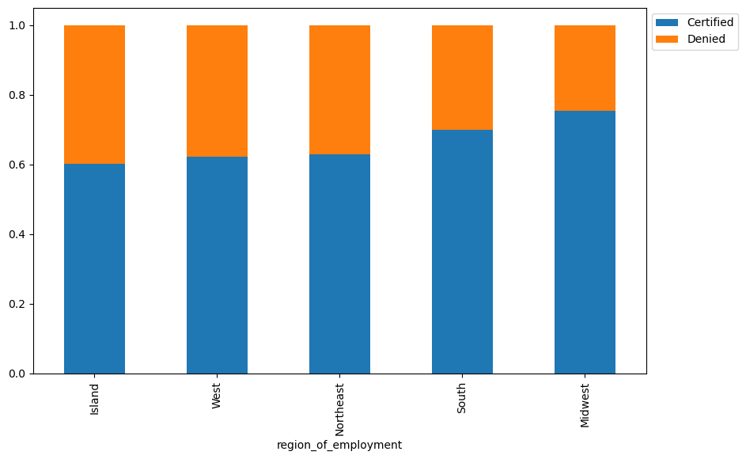

```python
stacked_barplot(df, "region_of_employment", "case_status")
```

The **Midwest** has the **highest approval rate**, followed by the **South**, indicating potentially favorable conditions for certification in these regions.

- The **West**, **Northeast**, and **Island** regions show **lower approval rates**, with the Island region having the **highest denial rate** (~40%).
- These trends may reflect differences in **job types, employer practices, or local labor market factors**.
- Region-specific features may enhance model predictions when included in training data.

### unit_of_wage VS case_status

```
case_status   Certified  Denied    All
unit_of_wage
All               17001    8446  25447
Year              16030    6903  22933
Hour                747    1406   2153
Week                169     103    272
Month                55      34     89
------------------------------------------------------------------------------------------------------------------------
```

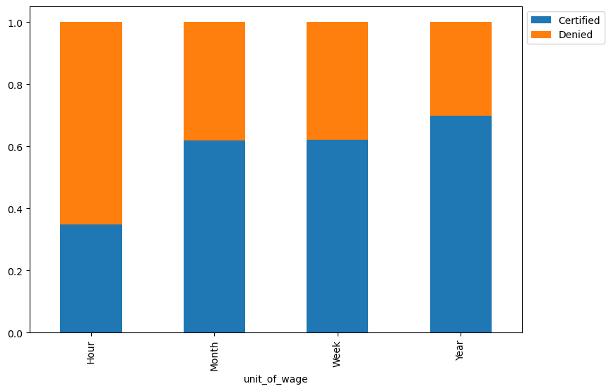

```python
stacked_barplot(df, "unit_of_wage", "case_status")
```

- **Yearly wage** cases have the **highest certification rate (~71%)**, likely reflecting salaried, full-time professional roles.
- **Hourly wage** positions are much more likely to be denied, with a **denial rate of ~65%**.
- **Weekly and monthly wage** units show intermediate certification rates but are far less common in the dataset.
- These trends indicate that **higher stability and predictability (e.g., yearly wages)** may be associated with higher approval rates.
- Including `unit_of_wage` as a feature could improve model performance, especially when paired with normalized wage values.

### full_time_position VS case_status

```
case_status         Certified  Denied    All
full_time_position
All                     17001    8446  25447
Y                       15146    7595  22741
N                        1855     851   2706
------------------------------------------------------------------------------------------------------------------------
```

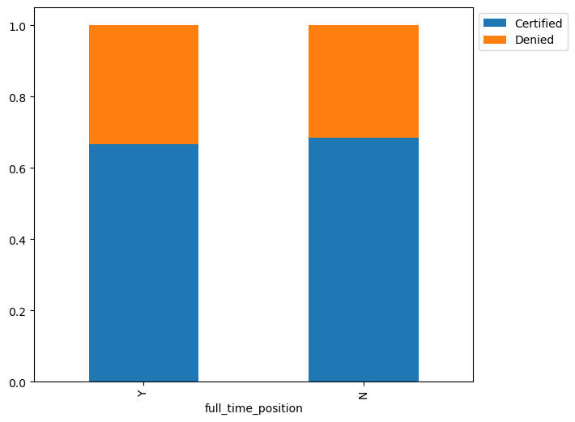

```python
stacked_barplot(df, "full_time_position", "case_status")
```

- The dataset shows a strong preference for **full-time positions** |
- Interestingly, the **certification rate for non-full-time positions is slightly higher**, despite being a much smaller subset (2,706 vs. 22,741 records).
- This suggests that while full-time roles dominate the dataset, **being full-time does not guarantee a higher approval rate**.
- The reason behind this might be influenced by other features such as wage, job role, or education level.
- Full-time status remains a relevant feature and may **interact with other variables** to impact case outcomes.

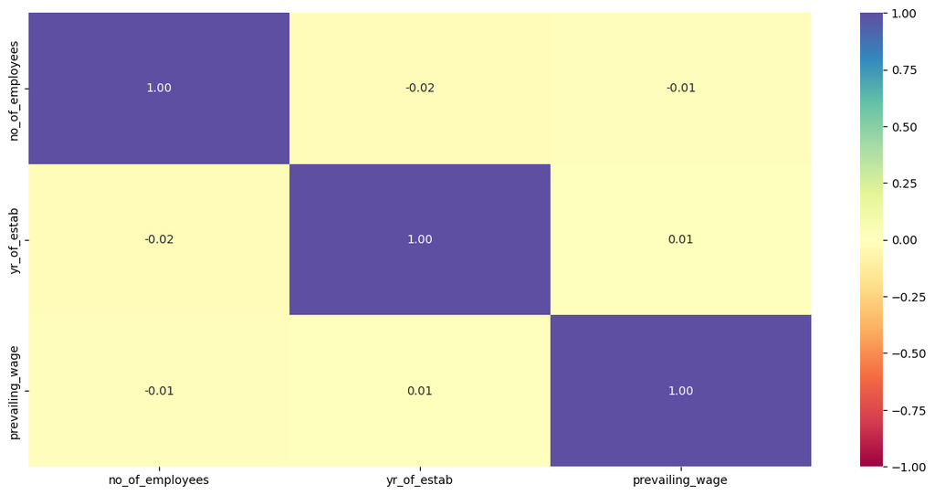

```python
plt.figure(figsize=(15, 7))
sns.heatmap(df.corr(numeric_only = True), annot=True, vmin=-1, vmax=1, fmt=".2f", cmap="Spectral")
plt.show()
```

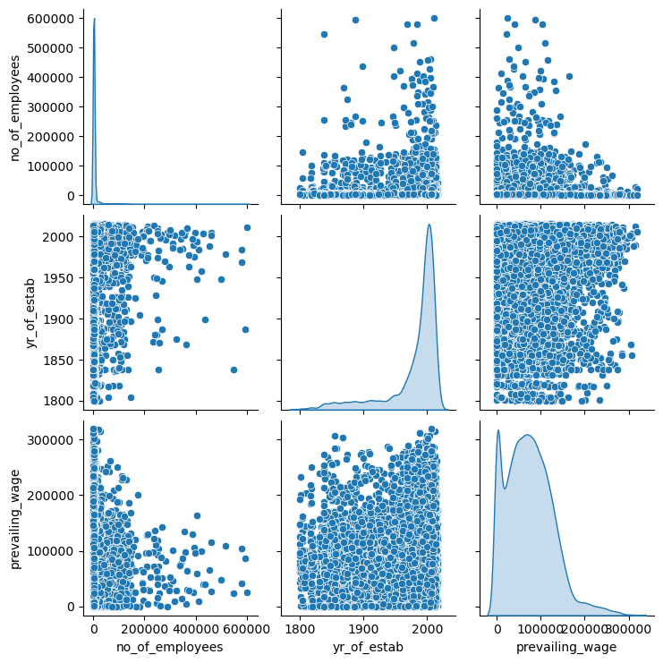

```python
sns.pairplot(data=df, diag_kind="kde")
plt.show()
```

### no_of_employees VS case_status

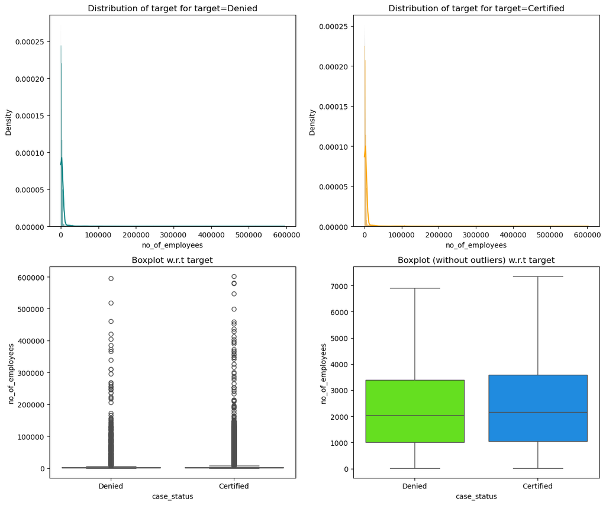

```python
distribution_plot_wrt_target(df, "no_of_employees", "case_status")
```

- The correlation matrix reveals **very weak linear relationships** among the three numeric features:  
  `no_of_employees`, `yr_of_estab`, and `prevailing_wage`.
- Key correlation values:
  - `no_of_employees` vs. `yr_of_estab`: **-0.02** (negligible negative correlation)
  - `no_of_employees` vs. `prevailing_wage`: **-0.01** (no meaningful relationship)
  - `yr_of_estab` vs. `prevailing_wage`: **0.01** (also negligible)
- All correlation values are extremely close to **zero**, suggesting that these variables are **not linearly correlated**.
- This implies that:
  - Multicollinearity is **not a concern** among these variables.
  - **Non-linear models** may be more effective in capturing interactions, if any exist.
- These features can still be valuable for prediction but may require transformation or interaction terms to improve performance in linear models.

### yr_of_estab VS case_status

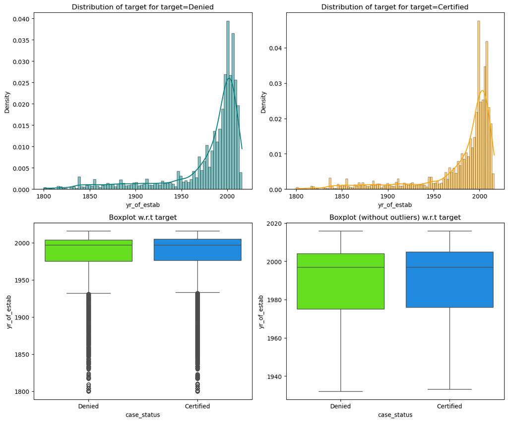

```python
distribution_plot_wrt_target(df, "yr_of_estab", "case_status")
```

### prevailing_wage VS case_status

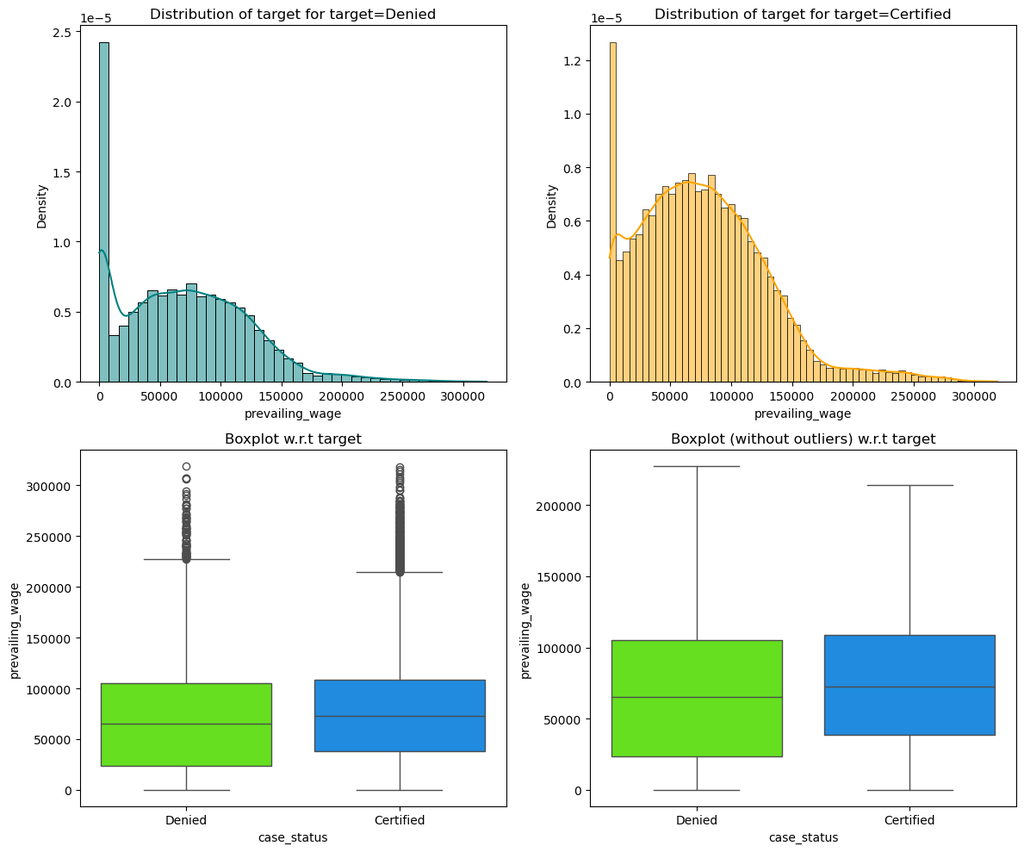

```python
distribution_plot_wrt_target(df, "prevailing_wage", "case_status")
```

- **Distribution plots** indicate:
  - Denied cases are concentrated more heavily at the **lower end of the wage spectrum**, especially below **$40,000**.
  - Certified cases have a **higher average prevailing wage**, with density peaking closer to **$70,000–$90,000**.
- **Boxplots (with and without outliers)** show:
  - The **median prevailing wage** is **higher for Certified cases** than for Denied cases.
  - Denied applications exhibit more cases with **very low wages**, which could negatively influence the likelihood of approval.
  - Both distributions are right-skewed with numerous **high-end outliers**.
- This analysis suggests that **higher wages are associated with a greater chance of certification**.
- Prevailing wage may be a **strong predictor** in classification models for `case_status`.
- It may be useful to apply **log transformation** or **binning** to handle skewness and outliers before modeling.

### What is the distribution of visa case statuses (certified vs. denied)?rates?

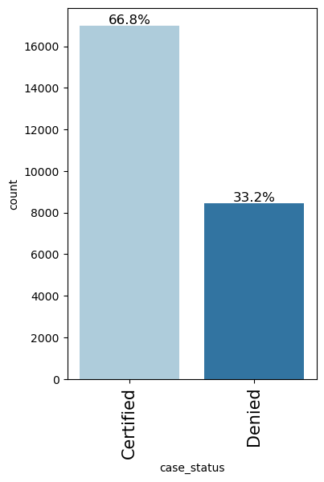

```python
labeled_barplot(df, "case_status", perc=True)
```

- Approximately **66.8%** of the applications in the dataset are **Certified**, indicating a relatively high approval rate.
- **33.2%** of the cases are **Denied**, representing a substantial portion of the dataset.

### How does the education level of employees impact visa approval rates?

```
case_status            Certified  Denied    All
education_of_employee
All                        17001    8446  25447
Bachelor's                  6362    3858  10220
High School                 1164    2252   3416
Master's                    7565    2057   9622
Doctorate                   1910     279   2189
------------------------------------------------------------------------------------------------------------------------
```

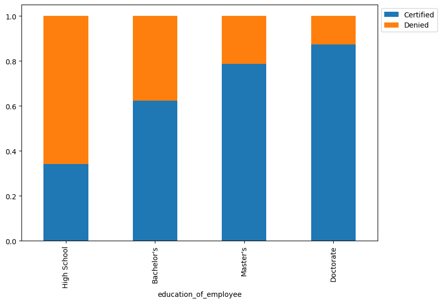

```python
stacked_barplot(df, "education_of_employee", "case_status")
```

- Applicants with only a **high school education have the lowest approval rate**, with **two-thirds of their applications denied**.
- In contrast, **Master’s and Doctorate holders enjoy much higher approval rates**, suggesting a strong link between **education level and visa approval success**.
- This trend is consistent and shows that **education is a powerful predictor** of certification outcomes in employment-based visa applicationnce.

### Is there a significant difference in visa approval rates between employees with and without prior job experience?

```
case_status         Certified  Denied    All
has_job_experience
All                     17001    8446  25447
N                        5986    4675  10661
Y                       11015    3771  14786
------------------------------------------------------------------------------------------------------------------------
```

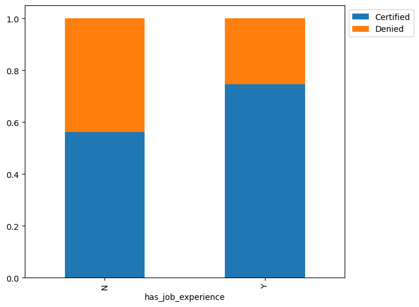

```python
stacked_barplot(df, "has_job_experience", "case_status")
```

- Among the 25,447 applications:
  - Applicants **with experience (`Y`)**: 11,015 certified out of 14,786 total
  - Applicants **without experience (`N`)**: 5,986 certified out of 10,661 total
- This clearly shows that **prior job experience significantly improves visa approval rates**.
- The difference in certification proportions indicates that **experience is a strong predictor** of a successful outcome and should be considered a **key feature in modeling or policy analysis**.

### How does the prevailing wage affect visa approval? Do higher wages lead to higher chances of approval?

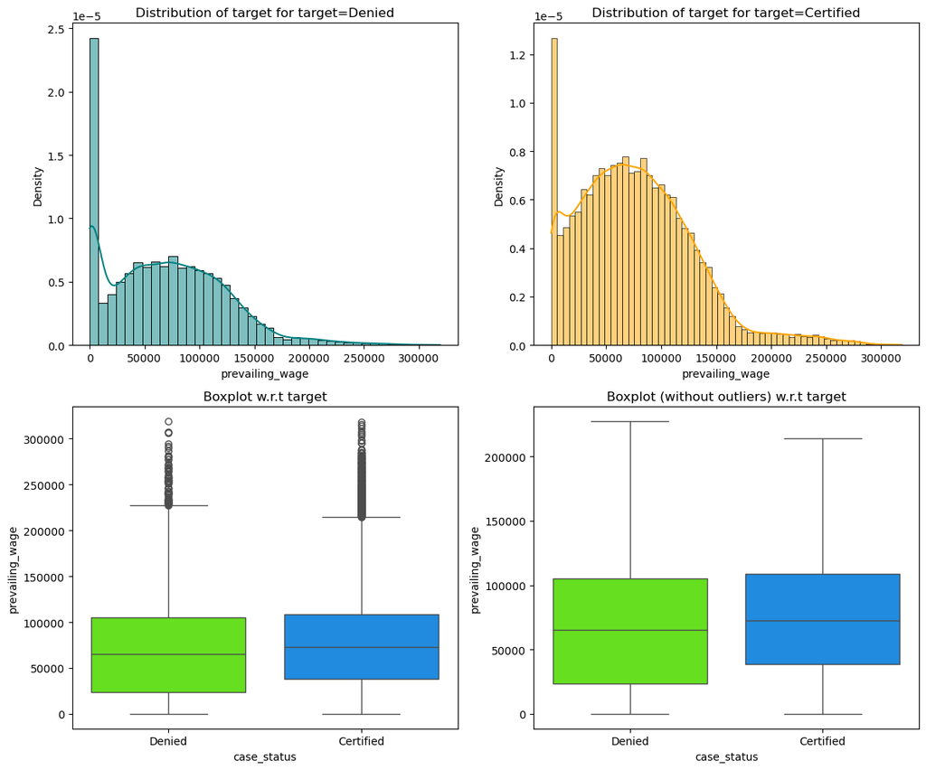

```python
distribution_plot_wrt_target(df, "prevailing_wage", "case_status")
```

- **Yes — higher prevailing wages are associated with higher visa approval rates.**

### Implications:

- **Prevailing wage is a strong predictor** of case outcome and should be considered a critical feature in predictive models.
- Applicants in **higher-paying positions** are more likely to have their cases certified, possibly reflecting job skill requirements or employer sponsorship credibility.
- **Normalization or log transformation** of wages may help in modeling due to the skewed distribution.

### Do certain regions in the US have higher visa approval rates compared to others?

```
case_status           Certified  Denied    All
region_of_employment
All                       17001    8446  25447
Northeast                  4524    2665   7189
West                       4097    2481   6578
South                      4908    2098   7006
Midwest                    3246    1053   4299
Island                      226     149    375
------------------------------------------------------------------------------------------------------------------------
```

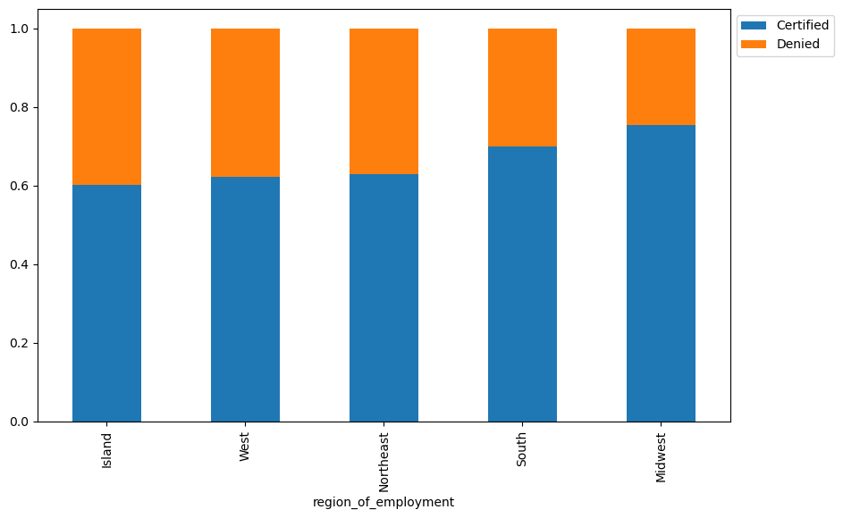

```python
stacked_barplot(df, "region_of_employment", "case_status")
```

[output not shown]

### How does the number of employees in a company influence visa approval? Do larger companies have a higher approval rate?

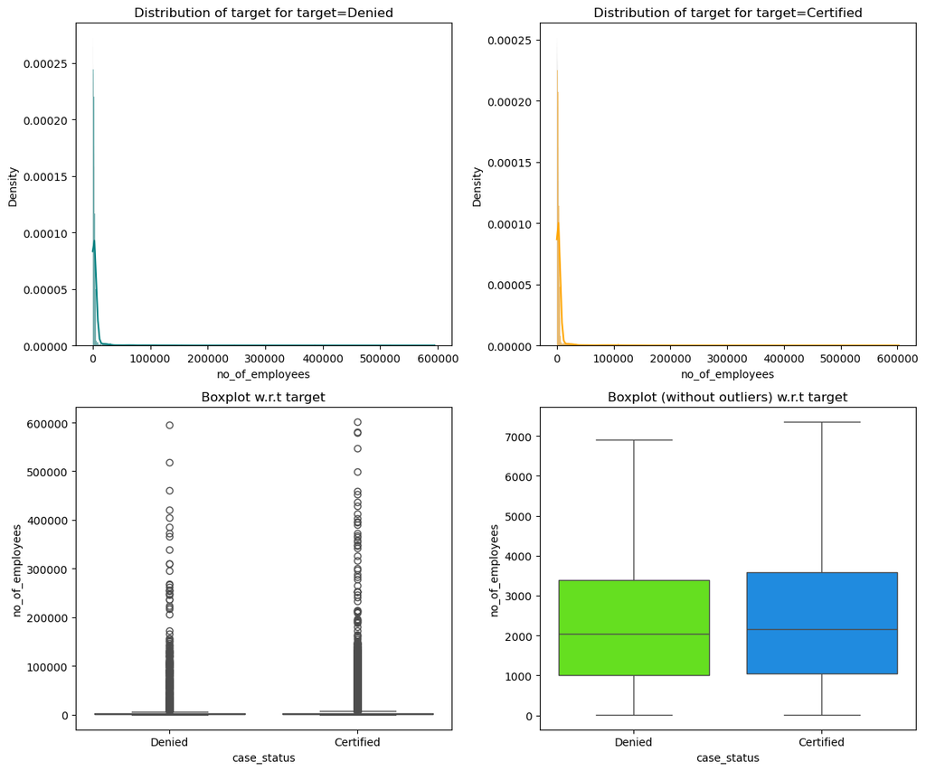

```python
distribution_plot_wrt_target(df, "no_of_employees", "case_status")
```

- Both **Certified** and **Denied** applications are **heavily right-skewed**, with most companies having **fewer than 10,000 employees**.
- A few extremely large companies (up to ~600,000 employees) act as **outliers**, but the bulk of the data lies in the **1,000–5,000 range**
- When outliers are excluded, the **median company size appears slightly higher for Certified cases** than Denied ones.
- However, the difference is **not very pronounced**, suggesting that **company size alone is not a strong standalone predictor** of visa approval.
- Larger companies may have **better approval processes or compliance**, but small to mid-size employers also get approvals..s.

```python
# Step 1: Define bins from 0 to 10,000 with step 1,000, plus an extra bin for >10,000
bins = list(range(0, 11_000, 1000)) + [np.inf]  # Adds an extra bin for >10,000
labels = [f'{bins[i]}-{int(bins[i+1])}' if bins[i+1] != np.inf else '10000+' for i in range(len(bins)-1)]

# Step 2: Bin the data
df['employee_bin'] = pd.cut(df['no_of_employees'], bins=bins, labels=labels, right=False)

# Step 3: Create pivot table
bin_counts = df.pivot_table(index='employee_bin', columns='case_status', aggfunc='size', fill_value=0)

# Step 4: Add row-wise totals
bin_counts['Total'] = bin_counts.sum(axis=1)

# Step 5: Add column-wise totals
total_row = pd.DataFrame(bin_counts.sum(axis=0)).T
total_row.index = ['Total']
bin_counts = pd.concat([bin_counts, total_row])

# Display final result
print(bin_counts)
```

```
case_status  Certified  Denied  Total
0-1000            4087    2115   6202
1000-2000         3877    2036   5913
2000-3000         3332    1648   4980
3000-4000         2343    1210   3553
4000-5000         1501     658   2159
5000-6000          649     246    895
6000-7000          142      38    180
7000-8000           31      13     44
8000-9000           26      15     41
9000-10000          30      14     44
10000+             983     453   1436
Total            17001    8446  25447
```

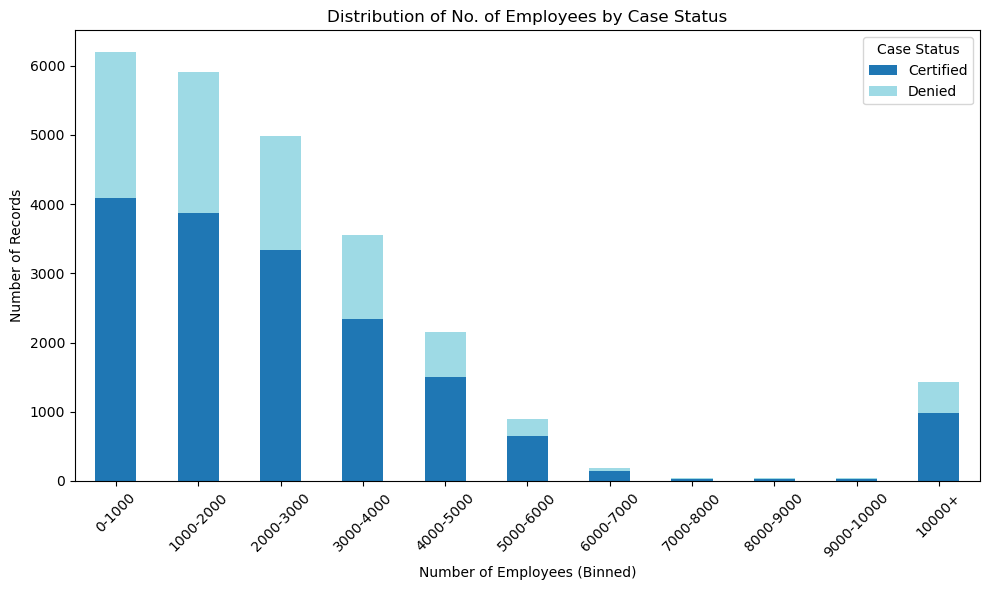

```python
# Step 3: Group data
bin_counts = df.pivot_table(index='employee_bin', columns='case_status', aggfunc='size', fill_value=0)

# Step 4: Plot histogram
bin_counts.plot(kind='bar', stacked=True, figsize=(10, 6), colormap='tab20')

# Step 5: Style the plot
plt.title('Distribution of No. of Employees by Case Status')
plt.xlabel('Number of Employees (Binned)')
plt.ylabel('Number of Records')
plt.xticks(rotation=45)
plt.legend(title='Case Status')
plt.tight_layout()

# Show plot
plt.show()
```

```python
large_companies = df[df['no_of_employees'] > 10_000]

# Смотрим распределение по ключевым признакам
features_to_explore = ['continent', 'education_of_employee', 'case_status',
                       'has_job_experience', 'requires_job_training', 'region_of_employment']

for feature in features_to_explore:
    print(f"\n--- {feature.upper()} ---")
    print(large_companies[feature].value_counts(dropna=False))
```

```
--- CONTINENT ---
continent
Asia             894
Europe           226
North America    220
South America     47
Africa            36
Oceania           13
Name: count, dtype: int64

--- EDUCATION_OF_EMPLOYEE ---
education_of_employee
Master's       604
Bachelor's     521
High School    181
Doctorate      130
Name: count, dtype: int64

--- CASE_STATUS ---
case_status
Certified    983
Denied       453
Name: count, dtype: int64

--- HAS_JOB_EXPERIENCE ---
has_job_experience
Y    846
N    590
Name: count, dtype: int64

--- REQUIRES_JOB_TRAINING ---
requires_job_training
N    1250
Y     186
Name: count, dtype: int64

--- REGION_OF_EMPLOYMENT ---
region_of_employment
Northeast    410
South        393
West         389
Midwest      205
Island        39
Name: count, dtype: int64
```